# Practical Machine Learning

Course Project

Sandro Henrique

29 setembro 2020

## Overview

### Background

Using devices such as Jawbone Up, Nike FuelBand, and Fitbit it is now possible to collect a large amount of data about personal activity relatively inexpensively. These type of devices are part of the quantified self movement – a group of enthusiasts who take measurements about themselves regularly to improve their health, to find patterns in their behavior, or because they are tech geeks. One thing that people regularly do is quantify how much of a particular activity they do, but they rarely quantify how well they do it. In this project, your goal will be to use data from accelerometers on the belt, forearm, arm, and dumbell of 6 participants. They were asked to perform barbell lifts correctly and incorrectly in 5 different ways.

The goal of this project is to **predict the manner in which they did the exercise**.

## Load Libraries and Data Download

```r
urlTrain <- "https://d396qusza40orc.cloudfront.net/predmachlearn/pml-training.csv"
urlTest <- "https://d396qusza40orc.cloudfront.net/predmachlearn/pml-testing.csv"


if (!file.exists("./pml-training.csv")) {
      download.file(urlTrain, destfile = "./pml-training.csv")
}

if (!file.exists("./pml-testing.csv")) {
      download.file(urlTest, destfile = "./pml-testing.csv")
}

DataTrain <- read.csv("./pml-training.csv")
DataTest <- read.csv("./pml-testing.csv")
```

## Exploratory Data Analysis and Data Cleaning

Before start feature preprocessing, let’s observe the descriptive statistics of each column in the training dataset.

```r
dim(DataTrain)
```

```
## [1] 19622   160
```

```r
dim(DataTest)
```

```
## [1]  20 160
```

```r
glimpse(DataTrain)
```

```
## Rows: 19,622
## Columns: 160
## $ X                        <int> 1, 2, 3, 4, 5, 6, 7, 8, 9, 10, 11, 12, 13,...
## $ user_name                <chr> "carlitos", "carlitos", "carlitos", "carli...
## $ raw_timestamp_part_1     <int> 1323084231, 1323084231, 1323084231, 132308...
## $ raw_timestamp_part_2     <int> 788290, 808298, 820366, 120339, 196328, 30...
## $ cvtd_timestamp           <chr> "05/12/2011 11:23", "05/12/2011 11:23", "0...
## $ new_window               <chr> "no", "no", "no", "no", "no", "no", "no", ...
## $ num_window               <int> 11, 11, 11, 12, 12, 12, 12, 12, 12, 12, 12...
## $ roll_belt                <dbl> 1.41, 1.41, 1.42, 1.48, 1.48, 1.45, 1.42, ...
## $ pitch_belt               <dbl> 8.07, 8.07, 8.07, 8.05, 8.07, 8.06, 8.09, ...
## $ yaw_belt                 <dbl> -94.4, -94.4, -94.4, -94.4, -94.4, -94.4, ...
## $ total_accel_belt         <int> 3, 3, 3, 3, 3, 3, 3, 3, 3, 3, 3, 3, 3, 3, ...
## $ kurtosis_roll_belt       <chr> "", "", "", "", "", "", "", "", "", "", ""...
## $ kurtosis_picth_belt      <chr> "", "", "", "", "", "", "", "", "", "", ""...
```

[output cut: 147 more lines]

Apparently there are a number of variables without relevant data, either empty or with NA. We will then remove variables with more than 90% of NA content.

```r
CleanDataTrain <- DataTrain[,colMeans(is.na(DataTrain)) < .9]
```

Additionally let’s **remove variables with low variance**, once predictors that only have a single unique value (i.e. a “zero-variance predictor”) or have only a handful of unique values that occur with very low frequencies does not help on get a good prediction and may cause crashes on some models or the fit to be unstable.

[output not shown]

Some models may benefit from **reducing the level of correlation** between the predictors.

```r
descrCor <- cor(CleanDataTrain[,1:51])
highlyCorData <- findCorrelation(descrCor, cutoff = .75)
CleanDataTrain <- CleanDataTrain[,-highlyCorData]

dim(CleanDataTrain)
```

```
## [1] 19622    32
```

### Training and Cross Validation Datasets

```r
idxTrain <- createDataPartition(y=CleanDataTrain$classe, p=0.7, list=F)
DtTrain <- CleanDataTrain[idxTrain,]
DtCV <- CleanDataTrain[-idxTrain,]
dim(DtTrain)
```

```
## [1] 13737    32
```

```r
dim(DtCV)
```

```
## [1] 5885   32
```

## Models Tests

Let’s use the most probable successful models for **Classification** : Decision Trees, Support Vector Machine, Gradient Boosted Trees, and Random Forest.

```r
control <- trainControl(method="cv", number=3, verboseIter=F)
```

### CART - Classification And Regression Tree

```r
CARTMeth <- train(classe ~ ., data=DtTrain, method="rpart",
                   trControl = control, tuneLength = 4)
pred_CART <- predict(CARTMeth, DtCV)
cmCART <- confusionMatrix(pred_CART, factor(DtCV$classe))
cmCART$overall[1]
```

```
##  Accuracy
## 0.5519116
```

### SVN - Support Vector Machine

```r
SVMMeth <- train(classe ~ ., data=DtTrain, method="svmLinear",
                 trControl = control, tuneLength = 4, verbose = F)


pred_SVM <- predict(SVMMeth, DtCV)

cmSVM <- confusionMatrix(pred_SVM, factor(DtCV$classe))

cmSVM$overall[1]
```

```
##  Accuracy
## 0.6351742
```

### GBM - Gradient Boosting Machine

```r
GBMMeth <- train(classe ~ ., data=DtTrain, method="gbm",
                 trControl = control, tuneLength = 5, verbose = F)


pred_GBM <- predict(GBMMeth, DtCV)

cmGBM <- confusionMatrix(pred_GBM, factor(DtCV$classe))

cmGBM$overall[1]
```

```
##  Accuracy
## 0.9802889
```

### RF - Random Forest

```r
RFMeth <- train(classe ~ ., data=DtTrain, method="rf",
                 trControl = control, tuneLength = 4, verbose = F)


pred_RF <- predict(RFMeth, DtCV)

cmRF <- confusionMatrix(pred_RF, factor(DtCV$classe))

cmRF$overall[1]
```

```
##  Accuracy
## 0.9884452
```

## Models Accuracy Evaluation

```r
cat(sprintf("Decision Trees:           %s\n", cmCART$overall[1]))
```

```
## Decision Trees:           0.551911639762107
```

```r
cat(sprintf("Support Vector Machine:   %s\n", cmSVM$overall[1]))
```

```
## Support Vector Machine:   0.63517417162277
```

```r
cat(sprintf("Gradient Boosted Machine: %s\n", cmGBM$overall[1]))
```

```
## Gradient Boosted Machine: 0.980288870008496
```

```r
cat(sprintf("Random Forest:            %s\n", cmRF$overall[1]))
```

```
## Random Forest:            0.988445199660153
```

Random Forest presented the best accuracy, around 98.9% and it will be used in our predictions for test dataset.

## Test Prediction

```r
TestPred <- predict(RFMeth, DataTest)
TestPred
```

```
##  [1] B A B A A E D B A A B C B A E E A B B B
## Levels: A B C D E
```

# Appendix

Verify variables density, quantiles, outliers and best methods performance.

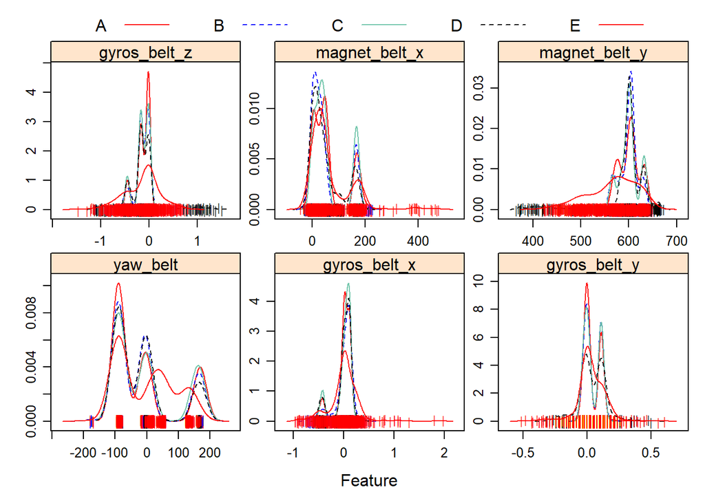

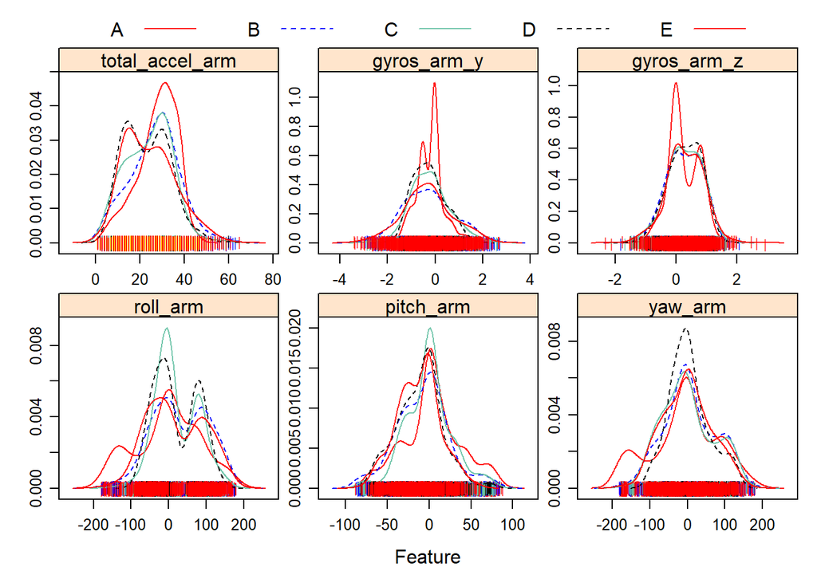

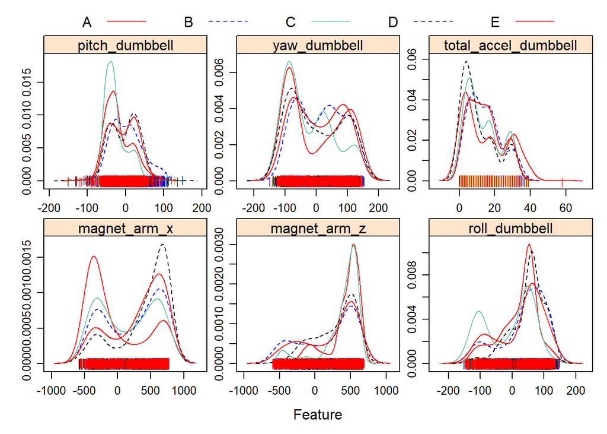

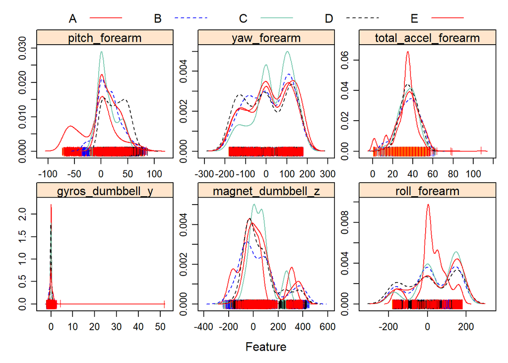

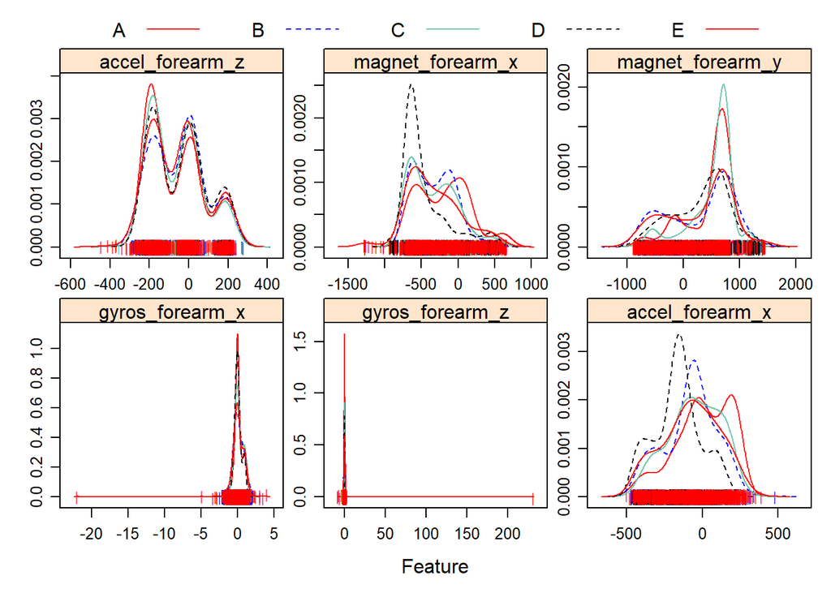

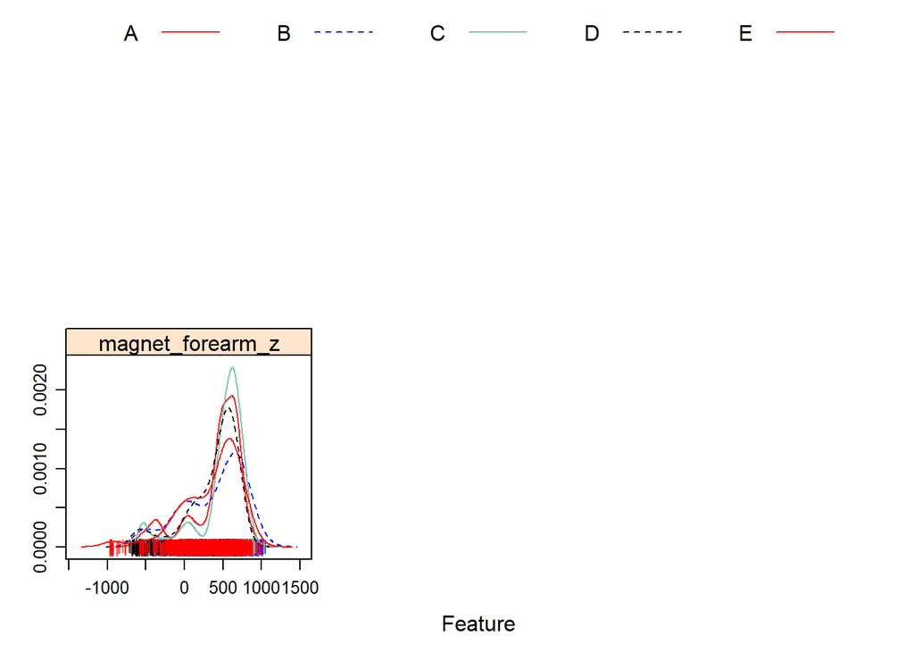

```r
transparentTheme(trans = .9)
featurePlot(x = DtCV[, 1:31],
            y = as.factor(DtCV$classe),
            plot = "density",
            scales = list(x = list(relation="free"),
                          y = list(relation="free")),
            adjust = 1.5,
            pch = "|",
            layout = c(3, 2),
            auto.key = list(columns = 5))
```

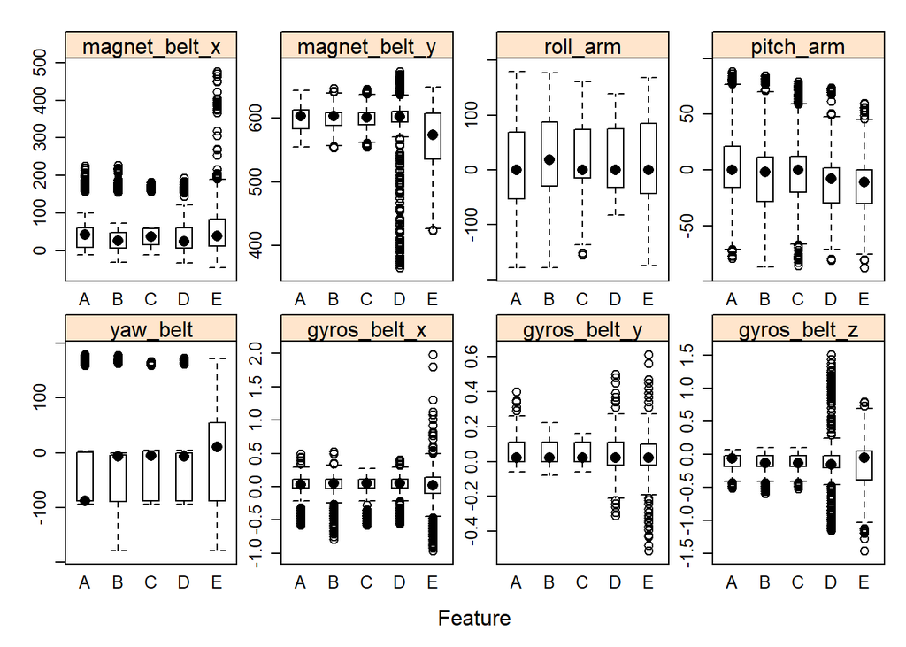

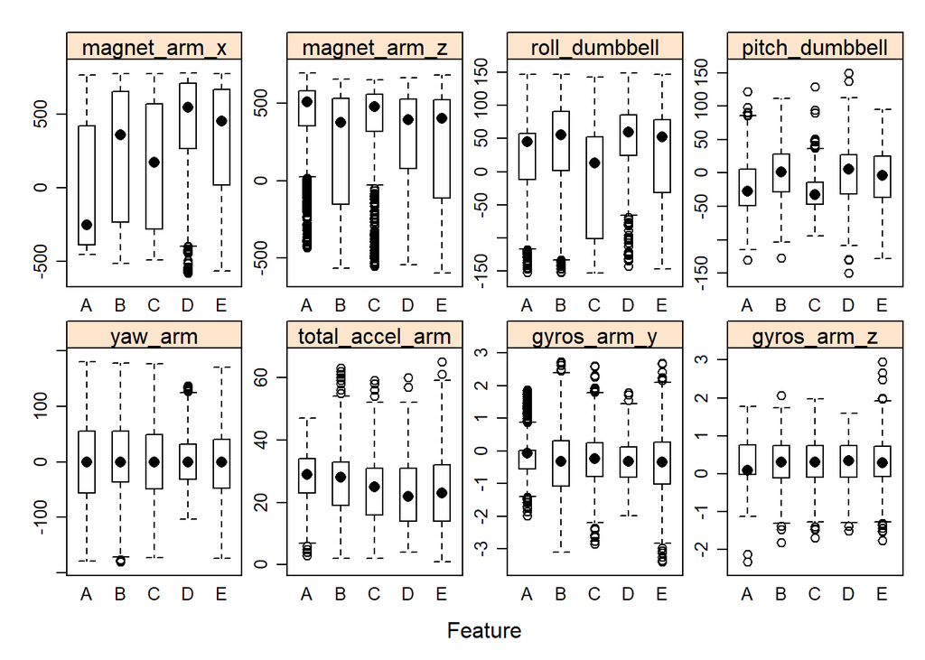

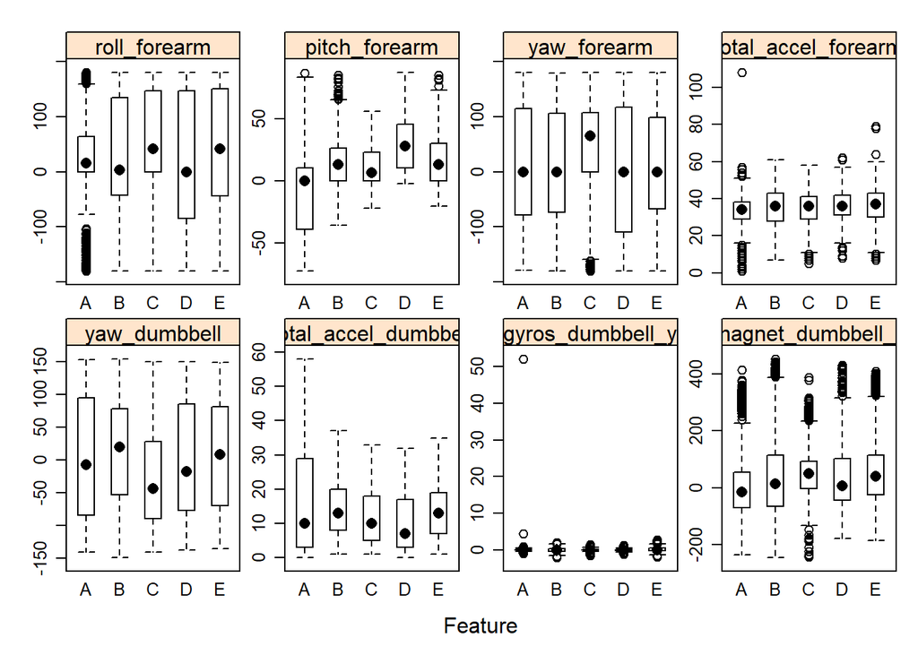

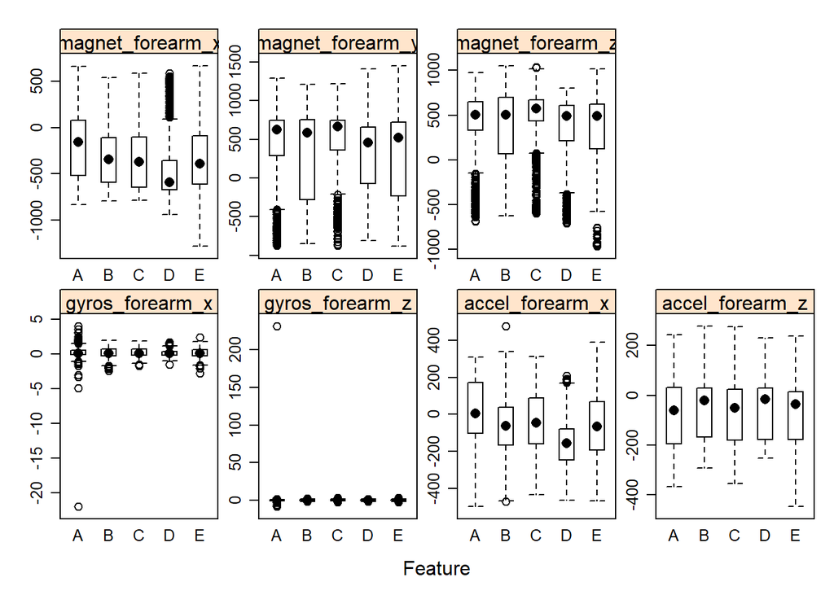

```r
featurePlot(x = DtCV[, 1:31],
            y = as.factor(DtCV$classe),
            plot = "box",
            type = c("p", "smooth"),
            scales = list(x = list(relation="free"),
                          y = list(relation="free")),
            adjust = 1.5,
            span = .5,
            layout = c(4, 2))
```

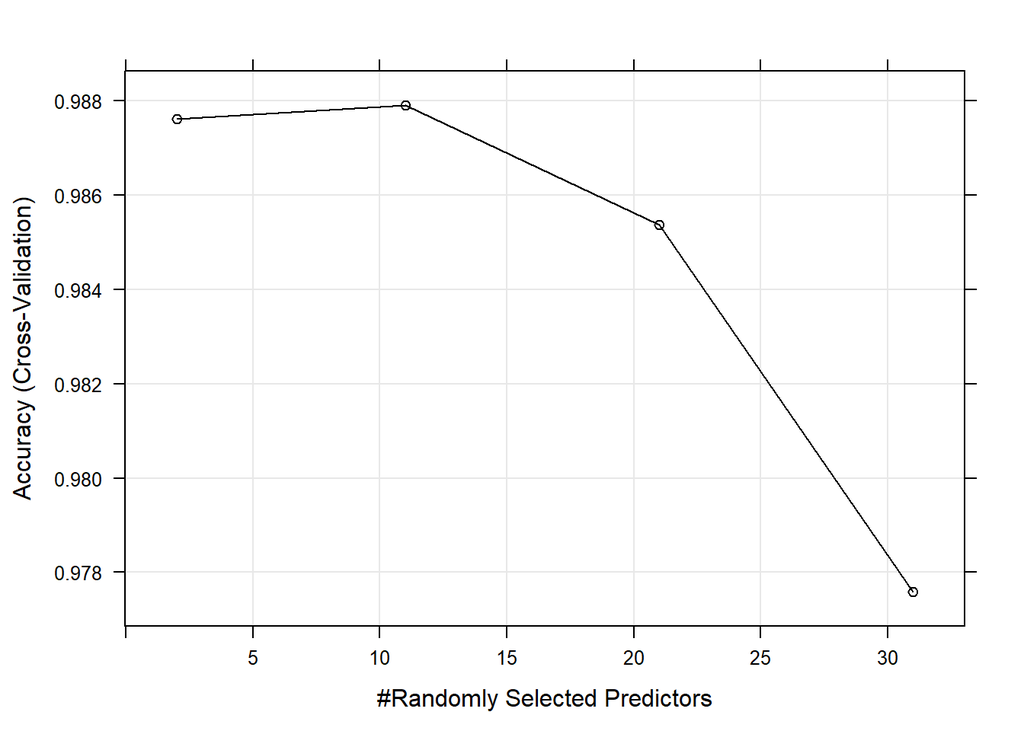

```r
plot(RFMeth)
```

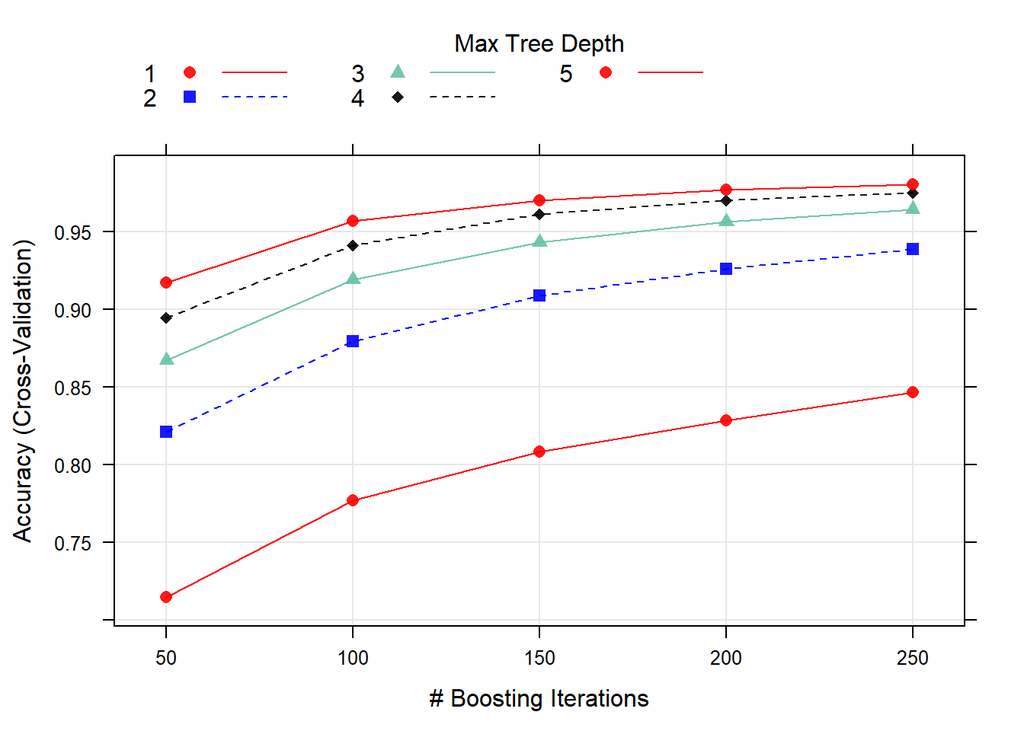

```r
plot(GBMMeth)
```